# PROJECT_9

## Twitter US Airline Sentiment - Problem Statement

### Background and Context:

Twitter possesses 330 million monthly active users, which allows businesses to reach a broad population and connect with customers without intermediaries. On the other hand, there’s so much information that it’s difficult for brands to quickly detect negative social mentions that could harm their business.

That's why sentiment analysis/classification, which involves monitoring emotions in conversations on social media platforms, has become a key strategy in social media marketing.

Listening to how customers feel about the product/service on Twitter allows companies to understand their audience, keep on top of what’s being said about their brand and their competitors, and discover new trends in the industry.

### Data Description:

A sentiment analysis job about the problems of each major U.S. airline was conducted. Twitter data was scraped from February of 2015 and contributors were asked to first classify positive, negative, and neutral tweets, followed by categorizing negative reasons (such as "late flight" or "rude service").

### Dataset:

The dataset has the following columns:

tweet_id  
airline_sentiment  
airline_sentiment_confidence  
negativereason  
negativereason_confidence  
airline  
airline_sentiment_gold  
name  
negativereason_gold retweet_count text tweet_coord tweet_created tweet_location user_timezone

### Objective:

To implement the techniques learned as a part of the course. We are to build a model that can predict the sentiment of each tweet about every major US airline in the data set. This will be of immense help to the social mdeia marketing of the airlines concerned.

```python
from google.colab import drive
drive.mount('/content/drive')
```

### Let's import relevant libraries

```python
 #for data manipulation and analysis
import numpy as np
import random
import pandas as pd
pd.set_option('display.max_colwidth', None) # Display full dataframe information (Non-turncated Text column.)
import matplotlib.pyplot as plt                                         # Used for plotting
import seaborn as sns                                                   # Used for plotting
from collections import Counter                                           # count the key-value pairs in an object

 #Used for Text PreProcessing
from wordcloud import WordCloud, STOPWORDS, ImageColorGenerator           # Used for plotting the wordcloud of a corpus
import nltk # Used for different task of NLP
nltk.download('stopwords')    #download stopwords
nltk.download('punkt')
nltk.download('wordnet')
from nltk.corpus import stopwords # Used for removal of stop words
from nltk.stem.wordnet import WordNetLemmatizer #Used for lemmatizing of words in the corpus
import contractions
import re, string, unicodedata
import wordcloud

#To convert the text data into number vectors
from sklearn.feature_extraction.text import TfidfVectorizer
from sklearn.feature_extraction.text import CountVectorizer

#To split the data set to train and test set
from sklearn.model_selection import train_test_split

#To build,evaluate and tune the model
from sklearn.ensemble import RandomForestClassifier
from sklearn.model_selection import KFold , StratifiedKFold, cross_val_score
from sklearn.metrics import accuracy_score
from sklearn.metrics import classification_report         # Import Classification report
from sklearn.model_selection import cross_val_score
from sklearn.metrics import confusion_matrix

from textblob import TextBlob
from nltk.sentiment.vader import SentimentIntensityAnalyzer


#to filter warnings
import warnings
warnings.filterwarnings("ignore")
```

```python
tweets_d=pd.read_csv('/content/drive/My Drive/Tweets.csv')  #Importing the data
tweets_d.head()#To display the first 5 rows in the data set
```

|  | tweet_id | airline_sentiment | airline_sentiment_confidence | negativereason | negativereason_confidence | airline | airline_sentiment_gold | name | negativereason_gold | retweet_count | text | tweet_coord | tweet_created | tweet_location | user_timezone |
| --- | --- | --- | --- | --- | --- | --- | --- | --- | --- | --- | --- | --- | --- | --- | --- |
| 0 | 570306133677760513 | neutral | 1.0000 | NaN | NaN | Virgin America | NaN | cairdin | NaN | 0 | @VirginAmerica What @dhepburn said. | NaN | 2015-02-24 11:35:52 -0800 | NaN | Eastern Time (US & Canada) |
| 1 | 570301130888122368 | positive | 0.3486 | NaN | 0.0000 | Virgin America | NaN | jnardino | NaN | 0 | @VirginAmerica plus you've added commercials to the experience... tacky. | NaN | 2015-02-24 11:15:59 -0800 | NaN | Pacific Time (US & Canada) |
| 2 | 570301083672813571 | neutral | 0.6837 | NaN | NaN | Virgin America | NaN | yvonnalynn | NaN | 0 | @VirginAmerica I didn't today... Must mean I need to take another trip! | NaN | 2015-02-24 11:15:48 -0800 | Lets Play | Central Time (US & Canada) |
| 3 | 570301031407624196 | negative | 1.0000 | Bad Flight | 0.7033 | Virgin America | NaN | jnardino | NaN | 0 | @VirginAmerica it's really aggressive to blast obnoxious "entertainment" in your guests' faces &amp; they have little recourse | NaN | 2015-02-24 11:15:36 -0800 | NaN | Pacific Time (US & Canada) |
| 4 | 570300817074462722 | negative | 1.0000 | Can't Tell | 1.0000 | Virgin America | NaN | jnardino | NaN | 0 | @VirginAmerica and it's a really big bad thing about it | NaN | 2015-02-24 11:14:45 -0800 | NaN | Pacific Time (US & Canada) |

- From the table above, it appears that the data set is in alliance with the data dictionary. While the column named 'text' contained the tweet of each client, the column 'airline_sentiment' contained the sentiment classification of the tweet.

```python
tweets_data=tweets_d.copy()#To save a copy of the original data set
```

```python
tweets_data.shape #To check the number of rows and columns in the data set
```

```
(14640, 15)
```

- There are 14,640 rows and 15 columns in the dataset

```python
tweets_data.info() #To print the summary of the data set
```

```
<class 'pandas.core.frame.DataFrame'>
RangeIndex: 14640 entries, 0 to 14639
Data columns (total 15 columns):
 #   Column                        Non-Null Count  Dtype
---  ------                        --------------  -----
 0   tweet_id                      14640 non-null  int64
 1   airline_sentiment             14640 non-null  object
 2   airline_sentiment_confidence  14640 non-null  float64
 3   negativereason                9178 non-null   object
 4   negativereason_confidence     10522 non-null  float64
 5   airline                       14640 non-null  object
 6   airline_sentiment_gold        40 non-null     object
 7   name                          14640 non-null  object
 8   negativereason_gold           32 non-null     object
 9   retweet_count                 14640 non-null  int64
 10  text                          14640 non-null  object
 11  tweet_coord                   1019 non-null   object
 12  tweet_created                 14640 non-null  object
 13  tweet_location                9907 non-null   object
 14  user_timezone                 9820 non-null   object
dtypes: float64(2), int64(2), object(11)
memory usage: 1.7+ MB
```

- It can be observed from the above that while some columns contained 14640 rows, some contain less numbers. This is an indication that those columns with less number of rows have missing values. We shall check for missing values using 'isna' method. The dataset also is a mix of integer, float and object data types.

```python
tweets_data.isnull().sum() #To check for missing values in the data set
```

```
tweet_id                            0
airline_sentiment                   0
airline_sentiment_confidence        0
negativereason                   5462
negativereason_confidence        4118
airline                             0
airline_sentiment_gold          14600
name                                0
negativereason_gold             14608
retweet_count                       0
text                                0
tweet_coord                     13621
tweet_created                       0
tweet_location                   4733
user_timezone                    4820
dtype: int64
```

- It is clear now that negativereason, negativereason_confidence, airline_sentiment_gold, negativereason_gold, tweet_coord, tweet_location, and user_timezone all contained missing values.

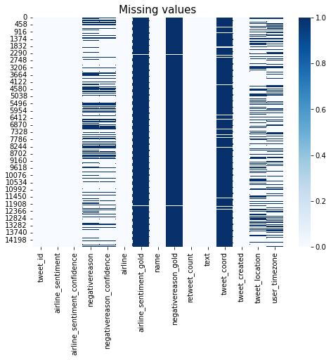

```python
#Visualization of missing value using heatmap
plt.figure(figsize=(8,6))
sns.heatmap(tweets_data.isnull(),cmap = "Blues")
plt.title("Missing values", fontsize = 15)
plt.show()
```

- The lines in the above heatmap visualize the location of missing values (i.e. the missing value indexes in the dataframe).

```python
def missing_zero_values_table(df):
        zero_val = (df == 0.00).astype(int).sum(axis=0)                                            # Number of zero in each column
        mis_val = df.isnull().sum()                                                                #Missing value in each column
        mis_val_percent = 100 * df.isnull().sum() / len(df)                                        #Missing value percent accross column
        mz_table = pd.concat([zero_val, mis_val, mis_val_percent], axis=1)                         #Concatenation of above aoutput
        mz_table = mz_table.rename(
        columns = {0 : 'Zero Values', 1 : 'Missing Values', 2 : '% of Total Values'})               #Renaming of each coumn
        mz_table['Total Zero Missing Values'] = mz_table['Zero Values'] + mz_table['Missing Values']  #column having total of zero value and missing values
        mz_table['% Total Zero Missing Values'] = 100 * mz_table['Total Zero Missing Values'] / len(df) # Column having percentage of totalof zero and missing value
        mz_table['Data Type'] = df.dtypes
        mz_table = mz_table[
            mz_table.iloc[:,1] != 0].sort_values(                                                     #Selecting and sorting those column which have at not a zero value in % of Total Values column
        '% of Total Values', ascending=False).round(1)
        print ("Your selected dataframe has " + str(df.shape[1]) + " columns and " + str(df.shape[0]) + " Rows.\n"
            "There are " + str(mz_table.shape[0]) +
              " columns that have missing values.")
#         mz_table.to_excel('D:/sampledata/missing_and_zero_values.xlsx', freeze_panes=(1,0), index = False)
        return mz_table

missing_zero_values_table(tweets_data)
```

```
Your selected dataframe has 15 columns and 14640 Rows.
There are 7 columns that have missing values.
```

|  | Zero Values | Missing Values | % of Total Values | Total Zero Missing Values | % Total Zero Missing Values | Data Type |
| --- | --- | --- | --- | --- | --- | --- |
| negativereason_gold | 0 | 14608 | 99.8 | 14608 | 99.8 | object |
| airline_sentiment_gold | 0 | 14600 | 99.7 | 14600 | 99.7 | object |
| tweet_coord | 0 | 13621 | 93.0 | 13621 | 93.0 | object |
| negativereason | 0 | 5462 | 37.3 | 5462 | 37.3 | object |
| user_timezone | 0 | 4820 | 32.9 | 4820 | 32.9 | object |
| tweet_location | 0 | 4733 | 32.3 | 4733 | 32.3 | object |
| negativereason_confidence | 1344 | 4118 | 28.1 | 5462 | 37.3 | float64 |

- The table above displays the percentage of missingness in each column containing missing values. Negativereason_gold, airline_sentiment_gold and tweet_coord contained more than 90% missing values.

```python
#Extracting the year,month, date,and hour from the tweet_created column
year=[]
month=[]
date=[]
hour=[]
for x in tweets_data['tweet_created']:
    year.append(int(x.split("-")[0]))                                          #extraction of year from date column and appending into list
    month.append(int(x.split("-")[1]))                                         #extraction of month from date column and appending into list
    date.append(int(x.split("-")[2].split(" ")[0]))                            #extraction of date of the month from date column and appending into list
    hour.append(int(x.split("-")[2].split(" ")[1].split(":")[0]))              #extraction of hour of that day from date column and appending into list

tweets_data['year']=year
tweets_data['month']=month
tweets_data['dates']=date
tweets_data['hour']=hour
tweets_data.head()
```

|  | tweet_id | airline_sentiment | airline_sentiment_confidence | negativereason | negativereason_confidence | airline | airline_sentiment_gold | name | negativereason_gold | retweet_count | text | tweet_coord | tweet_created | tweet_location | user_timezone | year | month | dates | hour |
| --- | --- | --- | --- | --- | --- | --- | --- | --- | --- | --- | --- | --- | --- | --- | --- | --- | --- | --- | --- |
| 0 | 570306133677760513 | neutral | 1.0000 | NaN | NaN | Virgin America | NaN | cairdin | NaN | 0 | @VirginAmerica What @dhepburn said. | NaN | 2015-02-24 11:35:52 -0800 | NaN | Eastern Time (US & Canada) | 2015 | 2 | 24 | 11 |
| 1 | 570301130888122368 | positive | 0.3486 | NaN | 0.0000 | Virgin America | NaN | jnardino | NaN | 0 | @VirginAmerica plus you've added commercials to the experience... tacky. | NaN | 2015-02-24 11:15:59 -0800 | NaN | Pacific Time (US & Canada) | 2015 | 2 | 24 | 11 |
| 2 | 570301083672813571 | neutral | 0.6837 | NaN | NaN | Virgin America | NaN | yvonnalynn | NaN | 0 | @VirginAmerica I didn't today... Must mean I need to take another trip! | NaN | 2015-02-24 11:15:48 -0800 | Lets Play | Central Time (US & Canada) | 2015 | 2 | 24 | 11 |
| 3 | 570301031407624196 | negative | 1.0000 | Bad Flight | 0.7033 | Virgin America | NaN | jnardino | NaN | 0 | @VirginAmerica it's really aggressive to blast obnoxious "entertainment" in your guests' faces &amp; they have little recourse | NaN | 2015-02-24 11:15:36 -0800 | NaN | Pacific Time (US & Canada) | 2015 | 2 | 24 | 11 |
| 4 | 570300817074462722 | negative | 1.0000 | Can't Tell | 1.0000 | Virgin America | NaN | jnardino | NaN | 0 | @VirginAmerica and it's a really big bad thing about it | NaN | 2015-02-24 11:14:45 -0800 | NaN | Pacific Time (US & Canada) | 2015 | 2 | 24 | 11 |

```python
tweets_data.describe(include='all')    # To print the statistical summary of the features in the data set
```

|  | tweet_id | airline_sentiment | airline_sentiment_confidence | negativereason | negativereason_confidence | airline | airline_sentiment_gold | name | negativereason_gold | retweet_count | text | tweet_coord | tweet_created | tweet_location | user_timezone | year | month | dates | hour |
| --- | --- | --- | --- | --- | --- | --- | --- | --- | --- | --- | --- | --- | --- | --- | --- | --- | --- | --- | --- |
| count | 1.464000e+04 | 14640 | 14640.000000 | 9178 | 10522.000000 | 14640 | 40 | 14640 | 32 | 14640.000000 | 14640 | 1019 | 14640 | 9907 | 9820 | 14640.0 | 14640.0 | 14640.000000 | 14640.000000 |
| unique | NaN | 3 | NaN | 10 | NaN | 6 | 3 | 7701 | 13 | NaN | 14427 | 832 | 14247 | 3081 | 85 | NaN | NaN | NaN | NaN |
| top | NaN | negative | NaN | Customer Service Issue | NaN | United | negative | JetBlueNews | Customer Service Issue | NaN | @united thanks | [0.0, 0.0] | 2015-02-24 09:54:34 -0800 | Boston, MA | Eastern Time (US & Canada) | NaN | NaN | NaN | NaN |
| freq | NaN | 9178 | NaN | 2910 | NaN | 3822 | 32 | 63 | 12 | NaN | 6 | 164 | 5 | 157 | 3744 | NaN | NaN | NaN | NaN |
| mean | 5.692184e+17 | NaN | 0.900169 | NaN | 0.638298 | NaN | NaN | NaN | NaN | 0.082650 | NaN | NaN | NaN | NaN | NaN | 2015.0 | 2.0 | 20.947473 | 12.319945 |
| std | 7.791112e+14 | NaN | 0.162830 | NaN | 0.330440 | NaN | NaN | NaN | NaN | 0.745778 | NaN | NaN | NaN | NaN | NaN | 0.0 | 0.0 | 2.170646 | 5.306285 |
| min | 5.675883e+17 | NaN | 0.335000 | NaN | 0.000000 | NaN | NaN | NaN | NaN | 0.000000 | NaN | NaN | NaN | NaN | NaN | 2015.0 | 2.0 | 16.000000 | 0.000000 |
| 25% | 5.685592e+17 | NaN | 0.692300 | NaN | 0.360600 | NaN | NaN | NaN | NaN | 0.000000 | NaN | NaN | NaN | NaN | NaN | 2015.0 | 2.0 | 19.000000 | 8.000000 |
| 50% | 5.694779e+17 | NaN | 1.000000 | NaN | 0.670600 | NaN | NaN | NaN | NaN | 0.000000 | NaN | NaN | NaN | NaN | NaN | 2015.0 | 2.0 | 22.000000 | 12.000000 |
| 75% | 5.698905e+17 | NaN | 1.000000 | NaN | 1.000000 | NaN | NaN | NaN | NaN | 0.000000 | NaN | NaN | NaN | NaN | NaN | 2015.0 | 2.0 | 23.000000 | 17.000000 |
| max | 5.703106e+17 | NaN | 1.000000 | NaN | 1.000000 | NaN | NaN | NaN | NaN | 44.000000 | NaN | NaN | NaN | NaN | NaN | 2015.0 | 2.0 | 24.000000 | 23.000000 |

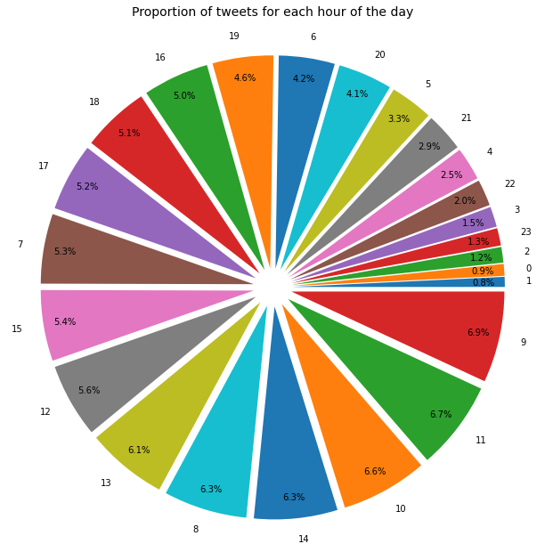

```python
#Using
Category=tweets_data['hour'].value_counts().sort_values()
pie, ax = plt.subplots(figsize=[20,11])
labels = Category.keys()
plt.pie(x=Category, autopct="%.1f%%", explode=[0.09]*24, labels=labels, pctdistance=0.9)
plt.title("Proportion of tweets for each hour of the day", fontsize=14);
#pie.savefig("DeliveryPieChart.png")
```

- The above chart shows that most of the tweets were done during daytime between 7am to 6pm. This might mean that there are more airline passengers during the day than nightime or that the daytime travellers and more active on socia media than nighttime travellers.

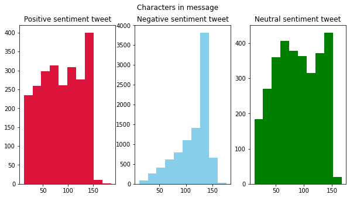

```python
#Plottting the %notebookumber of characters in tweets
fig,(ax1,ax2,ax3) = plt.subplots(1,3,figsize=(10,5))
tweet_len = tweets_data[tweets_data['airline_sentiment']=='positive']['text'].str.len()
ax1.hist(tweet_len,color='crimson')
ax1.set_title('Positive sentiment tweet')
tweet_len = tweets_data[tweets_data['airline_sentiment']=='negative']['text'].str.len()
ax2.hist(tweet_len,color='skyblue')
ax2.set_title('Negative sentiment tweet')
tweet_len = tweets_data[tweets_data['airline_sentiment']=='neutral']['text'].str.len()
ax3.hist(tweet_len,color='green')
ax3.set_title('Neutral sentiment tweet')
fig.suptitle('Characters in message')
```

- The negative sentiment tweets contain higher number of the characters than others. This suggests that most clients that tweet negative sentiments often narrate their 'bad experiences' in full.

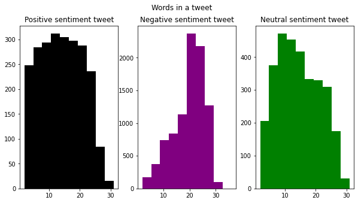

```python
#Plotting the number of words in a tweet
fig,(ax1,ax2,ax3) = plt.subplots(1,3,figsize=(10,5))
tweet_len = tweets_data[tweets_data['airline_sentiment']=='positive']['text'].str.split().map(lambda x: len(x))
ax1.hist(tweet_len, color='black')
ax1.set_title('Positive sentiment tweet')
tweet_len = tweets_data[tweets_data['airline_sentiment']=='negative']['text'].str.split().map(lambda x: len(x))
ax2.hist(tweet_len,color='purple')
ax2.set_title('Negative sentiment tweet')
tweet_len = tweets_data[tweets_data['airline_sentiment']=='neutral']['text'].str.split().map(lambda x: len(x))
ax3.hist(tweet_len,color='green')
ax3.set_title('Neutral sentiment tweet')
fig.suptitle('Words in a tweet')
```

- These histrograms above further confirms the negative sentiment tweets contain higher number of the words than others. The positve sentiments generally contain fewer words than others.

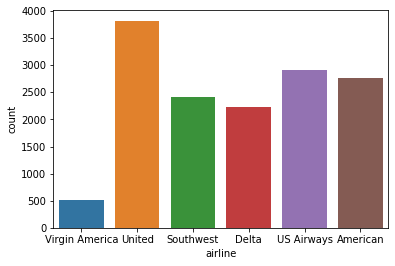

```python
sns.countplot(tweets_data['airline']);#Plotting the distribution of all tweets among each airline
```

- Most of the tweets are about United airline(more than 3500) while Virgin America has the least tweets. This can be a function of the level of patronage each airline enjoys.

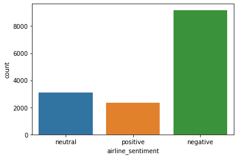

```python
sns.countplot(tweets_data['airline_sentiment']);#plotting the distribution of sentiment across all the tweets.
```

- The graph above shows that most of the tweets(above 8000) have negative sentiments while tweets with positive sentiments are the least in number in the data set. This means that customers tend to express bad experiences more than good ones.

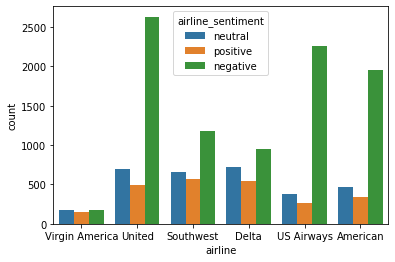

```python
sns.countplot(tweets_data['airline'],hue=tweets_data['airline_sentiment']);#Plotting the distribution of Sentiment of tweets for each airline
```

- The graph above shows that United airline, Us Airways, and American airlines are the top 3 airlines with highest negative sentiments. Virgin America has the least number across all the 3 sentiments when compared with other airlines. Also worthy of note is that positive sentiment tweets are the least in number across all airlines in the data set.

```python
# Frequency of unique values in negative reasons
Category=tweets_data['negativereason'].value_counts().sort_values()
Category
```

```
Damaged Luggage                  74
longlines                       178
Flight Attendant Complaints     481
Flight Booking Problems         529
Bad Flight                      580
Lost Luggage                    724
Cancelled Flight                847
Can't Tell                     1190
Late Flight                    1665
Customer Service Issue         2910
Name: negativereason, dtype: int64
```

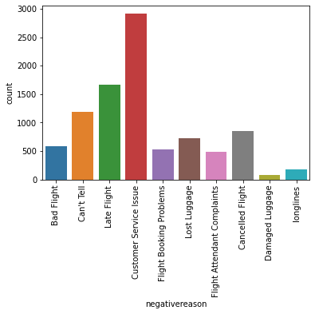

```python
plt.xticks(rotation=90)
sns.countplot(tweets_data['negativereason']); #Plotting the bar graph of the frequency distribution of negative reasons
```

- As earlier observed, the most given negative reason is Customer Service Issue accounting for over 2900 tweets while Damaged Luggage is the least given negative reason among air passengers(accounting for just 74 tweets). Late flights is the second most given negative reason in air passengers tweets. This means that all the major airline concerned need to work on improving their customer service and keeping to flight schedules.

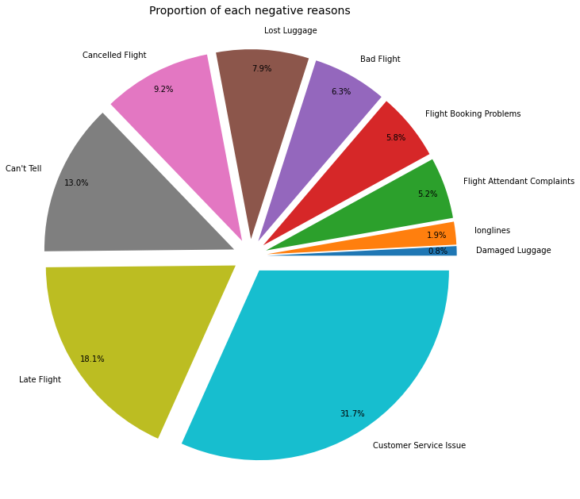

```python
##Plotting the pir chart of the frequency distribution of negative reasons
pie, ax = plt.subplots(figsize=[20,11])
labels = Category.keys()
plt.pie(x=Category, autopct="%.1f%%", explode=[0.09]*10, labels=labels, pctdistance=0.9)
plt.title("Proportion of each negative reasons", fontsize=14);
```

- The pie chart above further shows that Customer Service Issue and Late Flight account for approximately 50% of the negative reasons given while Damaged Luggage only accounts for 0.8%.

```python
#To drop all other columns except “text” and “airline_sentiment”
tweets = tweets_data[['airline_sentiment', 'text']]
tweets.head()#To show the first five rows in the new dataframe
```

|  | airline_sentiment | text |
| --- | --- | --- |
| 0 | neutral | @VirginAmerica What @dhepburn said. |
| 1 | positive | @VirginAmerica plus you've added commercials to the experience... tacky. |
| 2 | neutral | @VirginAmerica I didn't today... Must mean I need to take another trip! |
| 3 | negative | @VirginAmerica it's really aggressive to blast obnoxious "entertainment" in your guests' faces &amp; they have little recourse |
| 4 | negative | @VirginAmerica and it's a really big bad thing about it |

```python
tweets.shape#Checking the shape of the new data frame
```

```
(14640, 2)
```

- The new dataframe extracted contains 14640 rows and 2 columns as expected

## Data Preprocessing

### Removal of HTML Tags

```python
# Removal of the http link using Regular Expression.
for i, row in tweets.iterrows():
    clean_tweet = re.sub(r"http\S+", "", tweets.at[i, 'text'])
    tweets.at[i,'text'] = clean_tweet
tweets.head()#to print the first 5 rows
```

|  | airline_sentiment | text |
| --- | --- | --- |
| 0 | neutral | @VirginAmerica What @dhepburn said. |
| 1 | positive | @VirginAmerica plus you've added commercials to the experience... tacky. |
| 2 | neutral | @VirginAmerica I didn't today... Must mean I need to take another trip! |
| 3 | negative | @VirginAmerica it's really aggressive to blast obnoxious "entertainment" in your guests' faces &amp; they have little recourse |
| 4 | negative | @VirginAmerica and it's a really big bad thing about it |

### Replace contractions in string. (e.g. replace I'm --> I am) and so on

```python
def replace_contractions(text):
    """Replace contractions in string of text"""
    return contractions.fix(text)

# Perform the above operation over all the rows of tweet column of the dataframe.
for i, row in tweets.iterrows():
    content = tweets.at[i, 'text']
    clean_content = replace_contractions(content)
    tweets.at[i,'text'] = clean_content
tweets.head()#to print the first 5 rows
```

|  | airline_sentiment | text |
| --- | --- | --- |
| 0 | neutral | @VirginAmerica What @dhepburn said. |
| 1 | positive | @VirginAmerica plus you have added commercials to the experience... tacky. |
| 2 | neutral | @VirginAmerica I did not today... Must mean I need to take another trip! |
| 3 | negative | @VirginAmerica it is really aggressive to blast obnoxious "entertainment" in your guests' faces &amp; they have little recourse |
| 4 | negative | @VirginAmerica and it is a really big bad thing about it |

### Remove numbers

```python
def remove_numbers(text):
  text = re.sub(r'\d+', '', text)
  return text

tweets['text'] = tweets['text'].apply(lambda x: remove_numbers(x))
tweets.head()#to print the first 5 rows
```

|  | airline_sentiment | text |
| --- | --- | --- |
| 0 | neutral | @VirginAmerica What @dhepburn said. |
| 1 | positive | @VirginAmerica plus you have added commercials to the experience... tacky. |
| 2 | neutral | @VirginAmerica I did not today... Must mean I need to take another trip! |
| 3 | negative | @VirginAmerica it is really aggressive to blast obnoxious "entertainment" in your guests' faces &amp; they have little recourse |
| 4 | negative | @VirginAmerica and it is a really big bad thing about it |

### Tokenization of data

```python
tweets['text'] = tweets.apply(lambda row: nltk.word_tokenize(row['text']), axis=1) # Tokenization of data
tweets.head()#to print the first 5 rows
```

|  | airline_sentiment | text |
| --- | --- | --- |
| 0 | neutral | [@, VirginAmerica, What, @, dhepburn, said, .] |
| 1 | positive | [@, VirginAmerica, plus, you, have, added, commercials, to, the, experience, ..., tacky, .] |
| 2 | neutral | [@, VirginAmerica, I, did, not, today, ..., Must, mean, I, need, to, take, another, trip, !] |
| 3 | negative | [@, VirginAmerica, it, is, really, aggressive, to, blast, obnoxious, ``, entertainment, '', in, your, guests, ', faces, &, amp, ;, they, have, little, recourse] |
| 4 | negative | [@, VirginAmerica, and, it, is, a, really, big, bad, thing, about, it] |

### Remove the Non-ASCII Characters

```python
#remove the non-ASCII characters
def remove_non_ascii(words):
    """Remove non-ASCII characters from list of tokenized words"""
    new_words = []                        # Create empty list to store pre-processed words.
    for word in words:
        new_word = unicodedata.normalize('NFKD', word).encode('ascii', 'ignore').decode('utf-8', 'ignore')
        new_words.append(new_word)        # Append processed words to new list.
    return new_words
```

```python
tweets['text'] = tweets['text'].apply(lambda x: remove_non_ascii(x))
tweets.head()#to print the first 5 rows
```

|  | airline_sentiment | text |
| --- | --- | --- |
| 0 | neutral | [@, VirginAmerica, What, @, dhepburn, said, .] |
| 1 | positive | [@, VirginAmerica, plus, you, have, added, commercials, to, the, experience, ..., tacky, .] |
| 2 | neutral | [@, VirginAmerica, I, did, not, today, ..., Must, mean, I, need, to, take, another, trip, !] |
| 3 | negative | [@, VirginAmerica, it, is, really, aggressive, to, blast, obnoxious, ``, entertainment, '', in, your, guests, ', faces, &, amp, ;, they, have, little, recourse] |
| 4 | negative | [@, VirginAmerica, and, it, is, a, really, big, bad, thing, about, it] |

### Convert all characters to lowercase

```python
# convert all characters to lowercase
def to_lowercase(words):
    """Convert all characters to lowercase from list of tokenized words"""
    new_words = []                        # Create empty list to store pre-processed words.
    for word in words:
        new_word = word.lower()           # Converting to lowercase
        new_words.append(new_word)        # Append processed words to new list.
    return new_words
```

```python
tweets['text'] = tweets['text'].apply(lambda x: to_lowercase(x))
tweets.head()#to print the first 5 rows
```

|  | airline_sentiment | text |
| --- | --- | --- |
| 0 | neutral | [@, virginamerica, what, @, dhepburn, said, .] |
| 1 | positive | [@, virginamerica, plus, you, have, added, commercials, to, the, experience, ..., tacky, .] |
| 2 | neutral | [@, virginamerica, i, did, not, today, ..., must, mean, i, need, to, take, another, trip, !] |
| 3 | negative | [@, virginamerica, it, is, really, aggressive, to, blast, obnoxious, ``, entertainment, '', in, your, guests, ', faces, &, amp, ;, they, have, little, recourse] |
| 4 | negative | [@, virginamerica, and, it, is, a, really, big, bad, thing, about, it] |

### Remove the Punctuations

```python
# Remove the punctuations
def remove_punctuation(words):
    """Remove punctuation from list of tokenized words"""
    new_words = []                        # Create empty list to store pre-processed words.
    for word in words:
        new_word = re.sub(r'[^\w\s]', '', word)
        if new_word != '':
            new_words.append(new_word)    # Append processed words to new list.
    return new_words
```

```python
tweets['text'] = tweets['text'].apply(lambda x: remove_punctuation(x))
tweets.head()#to print the first 5 rows
```

|  | airline_sentiment | text |
| --- | --- | --- |
| 0 | neutral | [virginamerica, what, dhepburn, said] |
| 1 | positive | [virginamerica, plus, you, have, added, commercials, to, the, experience, tacky] |
| 2 | neutral | [virginamerica, i, did, not, today, must, mean, i, need, to, take, another, trip] |
| 3 | negative | [virginamerica, it, is, really, aggressive, to, blast, obnoxious, entertainment, in, your, guests, faces, amp, they, have, little, recourse] |
| 4 | negative | [virginamerica, and, it, is, a, really, big, bad, thing, about, it] |

### Remove the Stop Words

```python
# Remove the stop words
stopwords = stopwords.words('english')

customlist = ['not', "couldn't", 'didn', "didn't", 'doesn', "doesn't", 'hadn', "hadn't", 'hasn',
        "hasn't", 'haven', "haven't", 'isn', "isn't", 'ma', 'mightn', "mightn't", 'mustn',
        "mustn't", 'needn', "needn't", 'shan', "shan't", 'shouldn', "shouldn't", 'wasn',
        "wasn't", 'weren', "weren't", 'won', "won't", 'wouldn', "wouldn't"]

# Set custom stop-word's list as not, couldn't etc. words matter in Sentiment, so not removing them from original data.

stopwordz = list(set(stopwords) - set(customlist))
```

```python
def remove_stopwords(words):
    """Remove stop words from list of tokenized words"""
    new_words = []                        # Create empty list to store pre-processed words.
    for word in words:
        if word not in stopwordz:
            new_words.append(word)        # Append processed words to new list.
    return new_words
```

```python
tweets['text'] = tweets['text'].apply(lambda x: remove_stopwords(x))
tweets.head()#to print the first 5 rows
```

|  | airline_sentiment | text |
| --- | --- | --- |
| 0 | neutral | [virginamerica, dhepburn, said] |
| 1 | positive | [virginamerica, plus, added, commercials, experience, tacky] |
| 2 | neutral | [virginamerica, not, today, must, mean, need, take, another, trip] |
| 3 | negative | [virginamerica, really, aggressive, blast, obnoxious, entertainment, guests, faces, amp, little, recourse] |
| 4 | negative | [virginamerica, really, big, bad, thing] |

### Lemmatize the Words

```python
lemmatizer = WordNetLemmatizer()
```

```python
# lemmatize the words
def lemmatize_list(words):
    new_words = []
    for word in words:
        new_words.append(lemmatizer.lemmatize(word))
    return new_words

tweets['text'] = tweets['text'].apply(lambda x: lemmatize_list(x))
tweets.head()#to print the first 5 rows
```

|  | airline_sentiment | text |
| --- | --- | --- |
| 0 | neutral | [virginamerica, dhepburn, said] |
| 1 | positive | [virginamerica, plus, added, commercial, experience, tacky] |
| 2 | neutral | [virginamerica, not, today, must, mean, need, take, another, trip] |
| 3 | negative | [virginamerica, really, aggressive, blast, obnoxious, entertainment, guest, face, amp, little, recourse] |
| 4 | negative | [virginamerica, really, big, bad, thing] |

```python
#Applying the proprocesing steps to the text column once
def normalize(words):
    words = remove_non_ascii(words)
    words = to_lowercase(words)
    words = remove_punctuation(words)
    words = remove_stopwords(words)
    words = lemmatize_list(words)
    return ' '.join(words)

tweets['text'] = tweets.apply(lambda row: normalize(row['text']), axis=1)
tweets.head()#to print the first 5 rows
```

|  | airline_sentiment | text |
| --- | --- | --- |
| 0 | neutral | virginamerica dhepburn said |
| 1 | positive | virginamerica plus added commercial experience tacky |
| 2 | neutral | virginamerica not today must mean need take another trip |
| 3 | negative | virginamerica really aggressive blast obnoxious entertainment guest face amp little recourse |
| 4 | negative | virginamerica really big bad thing |

### Let's explore the common words in the tweets

```python
tweets['text'] = tweets.apply(lambda row: nltk.word_tokenize(row['text']), axis=1) # Tokenization of data
top = Counter([item for sublist in tweets['text'] for item in sublist])
freq = pd.DataFrame(top.most_common(20))#Finding the top 20 common words in the tweets
freq.columns = ['Common_words','count']
freq.style.background_gradient(cmap='Reds')
```

|  | Common_words | count |
| --- | --- | --- |
| 0 | flight | 4568 |
| 1 | united | 4160 |
| 2 | not | 3905 |
| 3 | usairways | 3051 |
| 4 | americanair | 2961 |
| 5 | southwestair | 2461 |
| 6 | jetblue | 2395 |
| 7 | get | 1376 |
| 8 | hour | 1161 |
| 9 | thanks | 1079 |
| 10 | cancelled | 1056 |
| 11 | service | 991 |
| 12 | time | 946 |
| 13 | customer | 934 |
| 14 | help | 872 |
| 15 | bag | 766 |
| 16 | u | 746 |
| 17 | would | 739 |
| 18 | plane | 726 |
| 19 | amp | 683 |

- From the table above, 'flight, united, and not' are the three most common words in all the tweets of air passengers in the data set. This suggests that United airline features prominently in the tweets.

```python
Positive_sent = tweets[tweets['airline_sentiment']=='positive'] #Defining positive sentiment tweets
Negative_sent = tweets[tweets['airline_sentiment']=='negative'] #Defining negative sentiment tweets
Neutral_sent = tweets[tweets['airline_sentiment']=='neutral'] #Defining neutral sentiment tweets
```

```python
#To print the number of tweets for each sentiment
print('Number of tweets with positive sentiment', Positive_sent['airline_sentiment'].count())
print('Number of tweets with negative sentiment', Negative_sent['airline_sentiment'].count())
print('Number of tweets with neutral sentiment', Neutral_sent['airline_sentiment'].count())
```

```
Number of tweets with positive sentiment 2363
Number of tweets with negative sentiment 9178
Number of tweets with neutral sentiment 3099
```

```python
#MosT common words in positive sentiment tweets
top = Counter([item for sublist in Positive_sent['text'] for item in sublist])
freq_positive = pd.DataFrame(top.most_common(20))#To display the top 20 most common words
freq_positive.columns = ['Common_words','count']
freq_positive.style.background_gradient(cmap='Greens')
```

|  | Common_words | count |
| --- | --- | --- |
| 0 | thanks | 609 |
| 1 | jetblue | 595 |
| 2 | southwestair | 576 |
| 3 | united | 528 |
| 4 | thank | 453 |
| 5 | flight | 436 |
| 6 | americanair | 355 |
| 7 | usairways | 276 |
| 8 | great | 236 |
| 9 | not | 199 |
| 10 | service | 163 |
| 11 | virginamerica | 156 |
| 12 | love | 150 |
| 13 | customer | 124 |
| 14 | guy | 123 |
| 15 | get | 120 |
| 16 | good | 109 |
| 17 | much | 109 |
| 18 | time | 107 |
| 19 | airline | 107 |

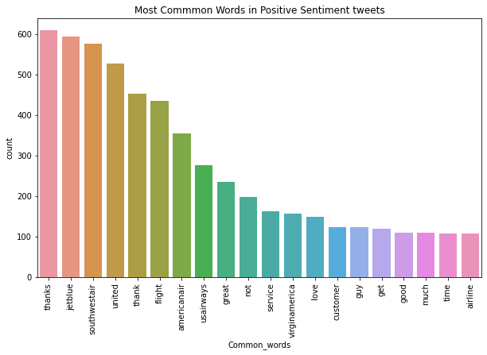

```python
#Plotting the bar charts of the most common words in positive sentiment tweets
fig, ax = plt.subplots(figsize=(10, 6))
sns.barplot(x='Common_words', y='count',
            data=freq_positive, ax=ax)
plt.title("Most Commmon Words in Positive Sentiment tweets")
plt.xticks(rotation='vertical');
```

- It can be observed from the table and the bar graphs above that words like 'thanks','jetblue',and 'southwestair' are the three most prominent words in the positive sentiments tweets.

```python
# To display most common words in the negative sentiment tweets
top = Counter([item for sublist in Negative_sent['text'] for item in sublist])
freq_negative = pd.DataFrame(top.most_common(20))
freq_negative.columns = ['Common_words','count']
freq_negative.style.background_gradient(cmap='flare')
```

|  | Common_words | count |
| --- | --- | --- |
| 0 | flight | 3357 |
| 1 | not | 3324 |
| 2 | united | 2895 |
| 3 | usairways | 2374 |
| 4 | americanair | 2107 |
| 5 | southwestair | 1214 |
| 6 | hour | 1107 |
| 7 | jetblue | 1052 |
| 8 | get | 1015 |
| 9 | cancelled | 920 |
| 10 | customer | 776 |
| 11 | service | 765 |
| 12 | time | 734 |
| 13 | bag | 660 |
| 14 | help | 619 |
| 15 | hold | 613 |
| 16 | plane | 594 |
| 17 | u | 521 |
| 18 | amp | 503 |
| 19 | call | 502 |

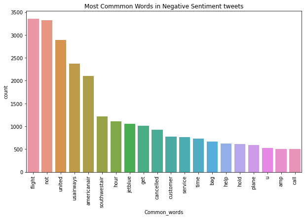

```python
# To plot the bar charts of most common words in the negative sentiment tweets
fig, ax = plt.subplots(figsize=(10, 6))
sns.barplot(x='Common_words', y='count',
            data=freq_negative, ax=ax)
plt.title("Most Commmon Words in Negative Sentiment tweets")
plt.xticks(rotation='vertical');
```

- From the table and graph above, 'flight, not and united' are the three most common words in the negative sentiment tweets of air passengers in the data set. This further suggests that United airline is the airline passengers negatively tweet about the most.

```python
#Displaying the most common words in the neutral tweets
top = Counter([item for sublist in Neutral_sent['text'] for item in sublist])
freq_neutral = pd.DataFrame(top.most_common(20))
freq_neutral.columns = ['Common_words','count']
freq_neutral.style.background_gradient(cmap='flare')
```

|  | Common_words | count |
| --- | --- | --- |
| 0 | flight | 775 |
| 1 | jetblue | 748 |
| 2 | united | 737 |
| 3 | southwestair | 671 |
| 4 | americanair | 499 |
| 5 | usairways | 401 |
| 6 | not | 382 |
| 7 | get | 241 |
| 8 | please | 181 |
| 9 | need | 180 |
| 10 | virginamerica | 177 |
| 11 | help | 167 |
| 12 | would | 166 |
| 13 | thanks | 156 |
| 14 | dm | 129 |
| 15 | u | 123 |
| 16 | ticket | 112 |
| 17 | tomorrow | 108 |
| 18 | fleek | 107 |
| 19 | know | 105 |

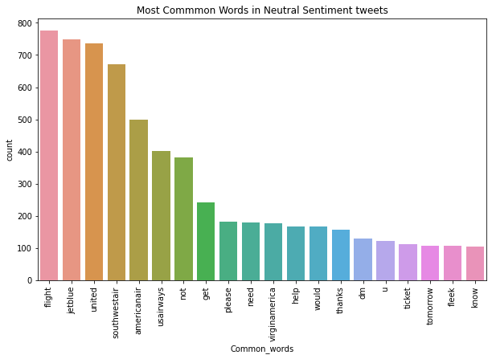

```python
#Plotting the bar graphs of the most common words in the neutral tweets
fig, ax = plt.subplots(figsize=(10, 6))
sns.barplot(x='Common_words', y='count',
            data=freq_neutral, ax=ax)
plt.title("Most Commmon Words in Neutral Sentiment tweets")
plt.xticks(rotation='vertical');
```

- The words like 'flight, jetblue, and united' are the three commonest words in the neutral sentiments tweets

```python
#Defining the function to plot the word cloud
def show_wordcloud(tweet_sentiment, title):
    text = ' '.join(tweet_sentiment['text'].astype(str).tolist())
    stopwords = set(wordcloud.STOPWORDS)

    fig_wordcloud = wordcloud.WordCloud(stopwords=stopwords,background_color='white',
                    colormap='viridis', width=800, height=600).generate(text)

    plt.figure(figsize=(14,11), frameon=True)
    plt.imshow(fig_wordcloud)
    plt.axis('off')
    plt.title(title, fontsize=30)
    plt.show()
```

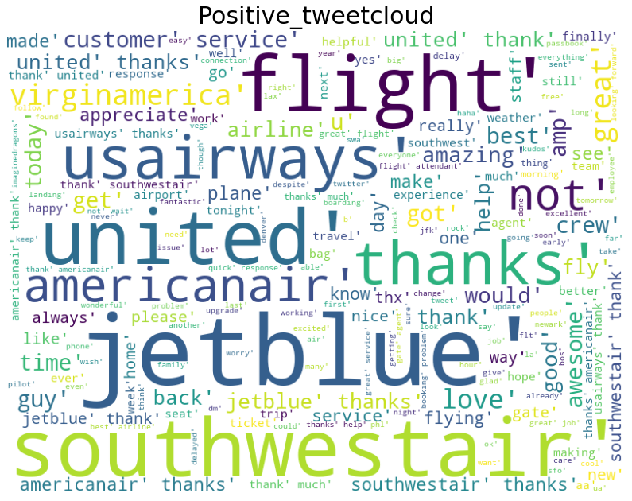

```python
show_wordcloud(Positive_sent, "Positive_tweetcloud")#Plotting the word cloud of Positive sentiments tweets
```

- **southwestair, jetblue, flight, thanks, united, americanair, great, best** were some of the important recurring words observed in the positive tweets

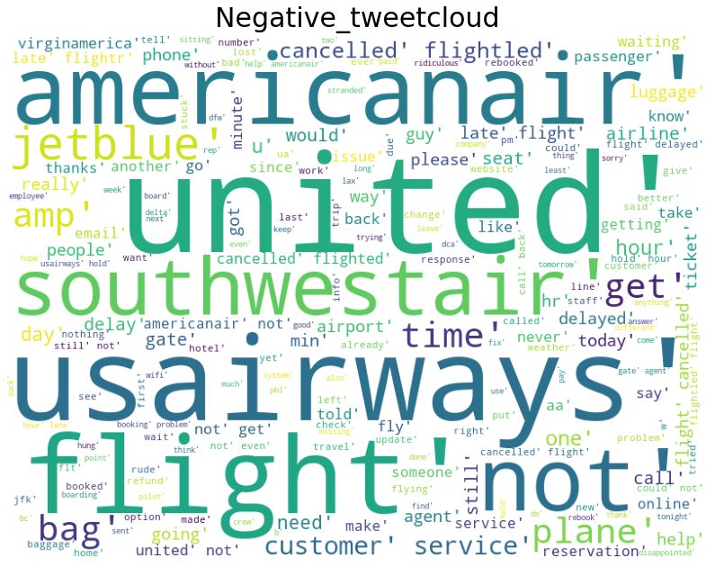

```python
show_wordcloud(Negative_sent, "Negative_tweetcloud")#Plotting the word cloud of negative sentiments tweets
```

- **united, flight, not, usairways, americanair, southwestair, jetblue, customer service** were some of the important recurring words observed in the negative tweets

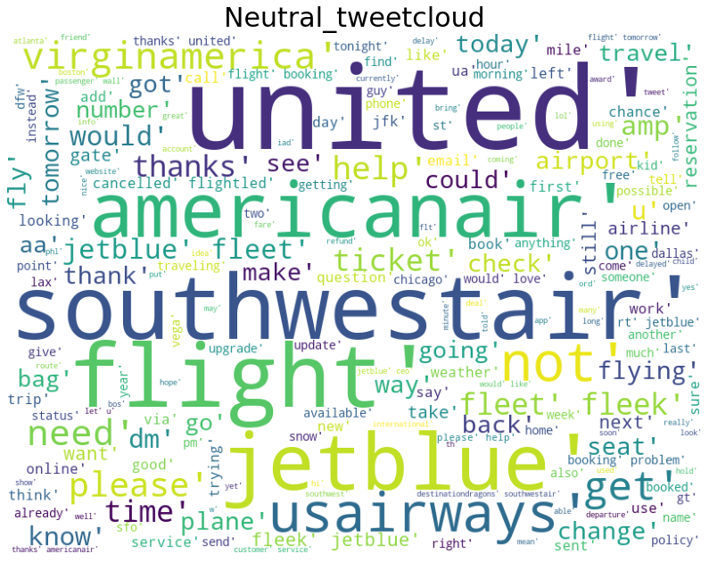

```python
show_wordcloud(Neutral_sent, "Neutral_tweetcloud")#Plotting the word cloud of neutral sentiments tweets
```

- **southwestair, jetblue, flight, thanks, united, americanair, usairways, virginamerica,please** were some of the important recurring words observed in the neutral tweets

## **Sentiment Analysis**

### **Using Bag of Words (CountVectorizer)**

```python
tweets['text'] = tweets['text'].astype(str)
# Vectorization (Convert text data to numbers).
vectorizer = CountVectorizer(max_features=2000)                # Keep only 2000 features as number of features will increase the processing time.
data_features = vectorizer.fit_transform(tweets['text'])
data_features = data_features.toarray()
```

```python
data_features.shape #Checking the shape of the final vectorised dataset
```

```
(14640, 2000)
```

```python
#Defining the predictors and the target feature
X = data_features #Defining the predictors

y = tweets.airline_sentiment #Defining the target feature
```

```python
# Split data into training and testing set.
X_train, X_test, y_train, y_test = train_test_split(X, y, test_size=0.25, random_state=42)
```

```python
# Using Random Forest with default parameters to build model for the classification of text.
# Also calculating the accuracy score on test set.

forest = RandomForestClassifier()

forest = forest.fit(X_train, y_train)

print(forest)

forest.score(X_test,y_test)
```

```
RandomForestClassifier()
```

```
0.7653005464480874
```

- The model built through randomforest classifier with default parameters gave an accuracy score of 0.77 on the test set. Let's tune number of estimator parameter in the model and check for improved performance.

```python
# Finding optimal number of base learners using k-fold Cross validation ->
base_ln = np.arange(100,500,100).tolist()
base_ln
```

```
[100, 200, 300, 400]
```

```python
# K-Fold Cross - validation .
cv_scores = []
for b in base_ln:
    clf = RandomForestClassifier(n_estimators = b)
    scores = cross_val_score(clf, X_train, y_train, cv = 5, scoring = 'accuracy')
    cv_scores.append(scores.mean())
```

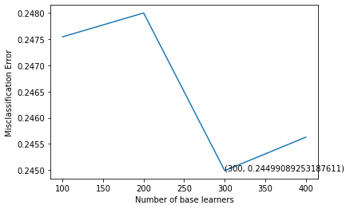

```python
# plotting the error as k increases
error = [1 - x for x in cv_scores]                                 #error corresponds to each number of estimator
optimal_learners = base_ln[error.index(min(error))]                #Selection of optimal number of n_estimator corresponds to minimum error.
plt.plot(base_ln, error)                                           #Plot between each number of estimator and misclassification error
xy = (optimal_learners, min(error))
plt.annotate('(%s, %s)' % xy, xy = xy, textcoords='data')
plt.xlabel("Number of base learners")
plt.ylabel("Misclassification Error")
plt.show()
```

```python
# Training the best model and calculating accuracy on test data .
clf = RandomForestClassifier(n_estimators = optimal_learners)
clf.fit(X_train, y_train)
clf.score(X_test, y_test)
count_vectorizer_predicted = clf.predict(X_test)
print(classification_report(y_test ,count_vectorizer_predicted , target_names = ['positive' , 'negative','neutral']))
print("Accuracy of the model is : ",accuracy_score(y_test,count_vectorizer_predicted))
```

```
              precision    recall  f1-score   support

    positive       0.82      0.90      0.86      2340
    negative       0.58      0.48      0.53       738
     neutral       0.72      0.62      0.67       582

    accuracy                           0.77      3660
   macro avg       0.71      0.67      0.69      3660
weighted avg       0.76      0.77      0.76      3660

Accuracy of the model is :  0.7710382513661203
```

- The best model used 300 estimators and gave an accuracy of 0.77 which is the same as the one built on default parameters.

```
[[2107  169   64]
 [ 309  357   72]
 [ 138   86  358]]
```

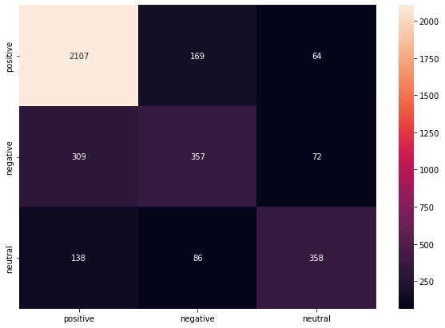

```python
# Print and plot Confusion matrix to get an idea of how the distribution of the prediction is, among all the classes.
conf_mat = confusion_matrix(y_test, count_vectorizer_predicted)

print(conf_mat)

df_cm = pd.DataFrame(conf_mat, index = [i for i in ['positive' , 'negative','neutral']],
                  columns = [i for i in ['positive' , 'negative','neutral']])
plt.figure(figsize = (10,7))
sns.heatmap(df_cm, annot=True, fmt='g')
```

### Let's check for the top 40 most important features based on our model

```
thank,thanks,not,hour,great,jetblue,usairways,flight,united,southwestair,awesome,customer,delayed,love,cancelled,bag,americanair,hold,virginamerica,amazing,get,delay,time,service,dm,call,please,still,best,day,hr,airline,would,worst,plane,help,good,never,need,one,
```

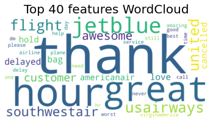

```python
all_features = vectorizer.get_feature_names()              #Instantiate the feature from the vectorizer
top_features=''                                            # Addition of top 40 feature into top_feature after training the model
feat=clf.feature_importances_
features=np.argsort(feat)[::-1]
for i in features[0:40]:
    top_features+=all_features[i]
    top_features+=','

print(top_features)  #to print the top 40 features

print(" ")
print(" ")

from wordcloud import WordCloud
wordcloud = WordCloud(background_color="white",colormap='viridis',width=2000,
                          height=1000).generate(top_features)

# Display the generated image:
plt.imshow(wordcloud, interpolation='bilinear')
plt.figure(1, figsize=(14, 11), frameon='equal')
plt.title('Top 40 features WordCloud', fontsize=20)
plt.axis("off")
plt.show()
```

- The word cloud above shows that features like 'great, thank, usairways, united, hour, jetblue, flight' ,among others are prominent among the top 40 features identified by the tuned model built.

### Using **TF-IDF Vectorizer**

**Term Frequency - Inverse Document Frequency:** It makes sure that less importance is given to the most frequent words, and it also considers less frequent words.

```python
# Using TfidfVectorizer to convert text data to numbers.

tfidf_vect = TfidfVectorizer(max_features=2000)#using only 2000 features from the data set
data_features = tfidf_vect.fit_transform(tweets['text'])

data_features = data_features.toarray()

data_features.shape     #feature shape
```

```
(14640, 2000)
```

```python
#Defining the predictors and the target feature
X = data_features

y = tweets.airline_sentiment
```

```python
# Split data into training and testing set.
X_train, X_test, y_train, y_test = train_test_split(X, y, test_size=0.25, random_state=42)
```

```python
# Using Random Forest with default parameters to build TF-IDF model for the classification of text.
# Also calculating the accuracy score on test set.

forest_2 = RandomForestClassifier()

forest_2 = forest_2.fit(X_train, y_train)

print(forest_2)

forest_2.score(X_test,y_test)
```

```
RandomForestClassifier()
```

```
0.7704918032786885
```

- The TF-IDF model on default parameters gave us 0.77 accuracy. This is still the same with the earlier Countvectorizer models built.

```python
# Finding optimal number of base learners using k-fold Crossvalidation ->
base_ln = np.arange(100,500,100).tolist()
base_ln
```

```
[100, 200, 300, 400]
```

```python
# K-Fold Cross - validation .
cv_scores = []
for b in base_ln:
    clf = RandomForestClassifier(n_estimators = b)
    scores = cross_val_score(clf, X_train, y_train, cv = 5, scoring = 'accuracy')
    cv_scores.append(scores.mean())
```

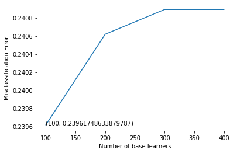

```python
# plotting the error as k increases
error = [1 - x for x in cv_scores]                                 #error corresponds to each nu of estimator
optimal_learners = base_ln[error.index(min(error))]                #Selection of optimal nu of n_estimator corresponds to minimum error.
plt.plot(base_ln, error)                                           #Plot between each nu of estimator and misclassification error
xy = (optimal_learners, min(error))
plt.annotate('(%s, %s)' % xy, xy = xy, textcoords='data')
plt.xlabel("Number of base learners")
plt.ylabel("Misclassification Error")
plt.show()
```

```python
# Training the best model and calculating accuracy on test data .
clf = RandomForestClassifier(n_estimators = optimal_learners)
clf.fit(X_train, y_train)
clf.score(X_test, y_test)
tf_idf_predicted = clf.predict(X_test)
print(classification_report(y_test , tf_idf_predicted , target_names = ['positive' , 'negative','neutral']))
print("Accuracy of the model is : ",accuracy_score(y_test,tf_idf_predicted))
```

```
              precision    recall  f1-score   support

    positive       0.80      0.94      0.86      2340
    negative       0.65      0.42      0.51       738
     neutral       0.77      0.56      0.65       582

    accuracy                           0.78      3660
   macro avg       0.74      0.64      0.67      3660
weighted avg       0.76      0.78      0.76      3660

Accuracy of the model is :  0.7751366120218579
```

- The model built using TF-IDF with 100 estimators gave an accuracy of 0.78 on the test set which is slightly better than the performance of the earlier models built. We shall therefore be going with this model.

```
[[2198   95   47]
 [ 373  313   52]
 [ 183   73  326]]
```

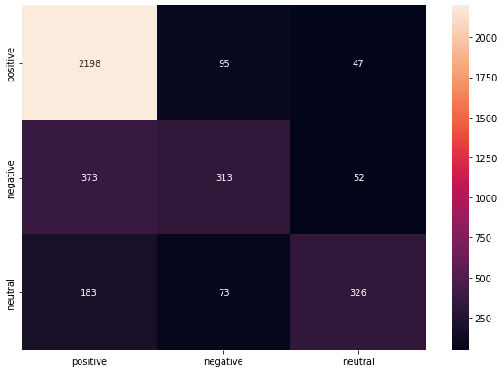

```python
# Print and plot Confusion matirx to get an idea of how the distribution of the prediction is, among all the classes.

conf_mat = confusion_matrix(y_test, tf_idf_predicted)

print(conf_mat)

df_cm = pd.DataFrame(conf_mat, index = [i for i in  ['positive' , 'negative','neutral']],
                  columns = [i for i in  ['positive' , 'negative','neutral']])
plt.figure(figsize = (10,7))
sns.heatmap(df_cm, annot=True, fmt='g')
```

[output not shown]

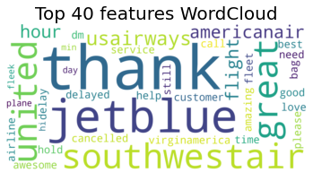

```python
#To plot the top 40 most important features in the dataset
all_features = tfidf_vect.get_feature_names()              #Instantiate the feature from the vectorizer
top_features=''                                            # Addition of top 40 feature into top_feature after training the model
feat=clf.feature_importances_
features=np.argsort(feat)[::-1]
for i in features[0:40]:
    top_features+=all_features[i]
    top_features+=', '

print(top_features)

print(" ")
print(" ")

wordcloud = WordCloud(background_color="white",colormap='viridis',width=2000,
                          height=1000).generate(top_features)

# Display the generated image:
plt.imshow(wordcloud, interpolation='bilinear')
plt.figure(1, figsize=(14, 11), frameon='equal')
plt.title('Top 40 features WordCloud', fontsize=20)
plt.axis("off")
plt.show()
```

- Features like 'thank, united, jetblue,southwestair,flight, usairways are prevalent among the top features

## **Comparing the accuracies of Count Vectorizer and TF-IDF**

```python
#convert the test samples into a dataframe where the columns are
#the y_test(ground truth labels),tf-idf model predicted labels(tf_idf_predicted),Count Vectorizer model predicted labels(count_vectorizer_predicted)
df = pd.DataFrame(y_test.tolist(),columns =['y_test'])
df['count_vectorizer_predicted'] = count_vectorizer_predicted
df['tf_idf_predicted'] = tf_idf_predicted
df.head()
```

|  | y_test | count_vectorizer_predicted | tf_idf_predicted |
| --- | --- | --- | --- |
| 0 | positive | positive | positive |
| 1 | negative | negative | negative |
| 2 | negative | negative | negative |
| 3 | neutral | neutral | neutral |
| 4 | negative | neutral | neutral |

- The performance of the two models(Countvectorizer and TF-IDF) are very similar. Both were able to predict correctly 4 out of 5 rows displayed which is a confirmation of the accuracy score(approximately 0.80) gotten for the two models

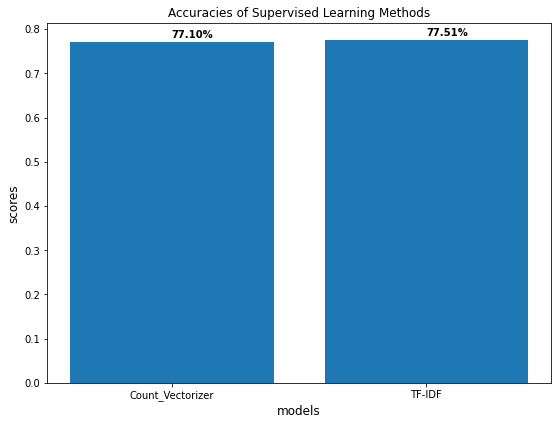

```python
#create bar plot to compare the accuracies of Count Vectorizer and TF-IDF
fig = plt.figure(figsize=(7,5))
ax = fig.add_axes([0,0,1,1])
subjects = ['Count_Vectorizer', 'TF-IDF']

# calculation accuracies of Count Vectorizer and TF-IDF using accuracy_score metrics
scores = [accuracy_score(y_test,count_vectorizer_predicted),accuracy_score(y_test,tf_idf_predicted)]
ax.bar(subjects,scores)
ax.set_ylabel('scores',fontsize= 12)    # y axis label
ax.set_xlabel('models',fontsize= 12)    # x axis label
ax.set_title('Accuracies of Supervised Learning Methods')  # tittle
for i, v in enumerate(scores):
    ax.text( i ,v+0.01, '{:.2f}%'.format(100*v), color='black', fontweight='bold')
    plt.savefig('barplot_1.png',dpi=100, format='png', bbox_inches='tight')
plt.show()
```

- **Tuned TF-IDF model shows a slightly better performance than Count Vectorizer**, because it not only focuses on the frequency of words present in the corpus but also provides the importance of the words. We can then remove the words that are less important for analysis, hence making the model building less complex by reducing the input dimensions.

## Conclusion

**Summary from the understanding of the application of various Pre-processing, Vectorization, and performance of the model on the dataset are listed below:**

- Most of the tweets were done during daytime between 7am to 6pm. This might mean that there are more airline passengers during the day than nightime or that the daytime travellers and more active on socia media than nighttime travellers.
- United airline, Us Airways, and American airlines are the top 3 airlines with highest negative sentiments. Virgin America has the least number across all the 3 sentiments when compared with other airlines. Also worthy of note is that positive sentiment tweets are the least in number across all airlines in the data set.
- The most given negative reason is Customer Service Issue accounting for over 2900 tweets while Damaged Luggage is the least given negative reason among air passengers(accounting for just 74 tweets). Late flights is the second most given negative reason in air passengers tweets. Customer Service Issue and Late Flight account for approximately 50% of the negative reasons given while Damaged Luggage only accounts for 0.8%. This means that all the major airline concerned need to work on improving their customer service and keeping to flight schedules.
- Words like 'thanks','jetblue',and 'southwestair' are the three most prominent words in the positive sentiments tweets.
- 'flight, not, and united' are the three most common words in the negative sentiment tweets of air passengers in the data set. This further suggests that United airline is the airline that passengers negatively tweet about the most.
- Our best model(tuned TF-IDF) gave an accuracy of 0.78 which is reasonable but can be improved upon because the model was built with only 2000 features from the over 11,000 present in the data set.
- The best model shows that features like 'great, thank, usairways, united, hour, jetblue, flight' ,among others are prominent among the top 40 features identified by the model built.